# Mass univariate testing and nested data frames

Often we want to run a whole series of tests across multiple timepoints, electrodes, frequency bands etc.

Just as in other languages, in R, we can iterate can over vectors and lists, performing the same operation on each item in the list, using *for* loops. But R has its own way of doing this that avoids explicitly specifying *for* loops. In base R, there is the *apply()* family of commands. We’ll be using the *map()* family of commands from the **purrr** package, part of the **tidyverse**.

## Packages and commands

You’ll need to load the following packages * tidyverse * broom

We’ll be using the following new commands * map()/map_df() * nest()/unnest()

```r
library(tidyverse)
library(broom)
load('../user_data/final_df.Rdata')
```

## Nested data frames

*Nest()* from *tidyr* turns several columns of a dataframe into a single column that is a list of dataframes.

Create a nested data frame for each time point.

```r
time_nest <- nest(final_df, -Time)
head(time_nest)
```

```
## # A tibble: 6 x 2
##      Time              data
##     <dbl>            <list>
## 1 -199.22 <tibble [90 x 4]>
## 2 -197.27 <tibble [90 x 4]>
## 3 -195.31 <tibble [90 x 4]>
## 4 -193.36 <tibble [90 x 4]>
## 5 -191.41 <tibble [90 x 4]>
## 6 -189.45 <tibble [90 x 4]>
```

### Map() and looping

*map()* commands from **purrr** iterate through the elements of lists and vectors, applying functions to each element and returning a specific type of output (e.g. *map()* itself returns a list; *map_dbl()* returns a number in double format; *map_df()* returns a dataframe). We’ll add an extra column to our nested data frame containing the output of the t.test() function applied to each element of the *data* list within the time_nest frame.

```r
time_nest <- mutate(time_nest,
                    stats = map(data, ~t.test(amplitude ~ Object,
                                              paired = TRUE, data = .x)))
head(time_nest)
```

```
## # A tibble: 6 x 3
##      Time              data       stats
##     <dbl>            <list>      <list>
## 1 -199.22 <tibble [90 x 4]> <S3: htest>
## 2 -197.27 <tibble [90 x 4]> <S3: htest>
## 3 -195.31 <tibble [90 x 4]> <S3: htest>
## 4 -193.36 <tibble [90 x 4]> <S3: htest>
## 5 -191.41 <tibble [90 x 4]> <S3: htest>
## 6 -189.45 <tibble [90 x 4]> <S3: htest>
```

We now have a data frame with the results of the t.test function for each timepoint. Suppose you now want to retrieve the t.test results for a specific timepoint. You can access list elements using double brackets [[]]; you would need to find the right row number for the timepoint you want, and enclose that in the brackets.

```r
time_nest$stats[[10]]
```

```
##
##  Paired t-test
##
## data:  amplitude by Object
## t = -0.15799, df = 44, p-value = 0.8752
## alternative hypothesis: true difference in means is not equal to 0
## 95 percent confidence interval:
##  -0.2958799  0.2528616
## sample estimates:
## mean of the differences
##             -0.02150914
```

Alternatively, we can use map to iterate through the list and extract, for example, each p-value.

```r
time_nest %>%
  mutate(pvals = map_dbl(stats, "p.value"))
```

```
## # A tibble: 409 x 4
##       Time              data       stats     pvals
##      <dbl>            <list>      <list>     <dbl>
##  1 -199.22 <tibble [90 x 4]> <S3: htest> 0.9833242
##  2 -197.27 <tibble [90 x 4]> <S3: htest> 0.9758160
##  3 -195.31 <tibble [90 x 4]> <S3: htest> 0.9580694
##  4 -193.36 <tibble [90 x 4]> <S3: htest> 0.9572556
##  5 -191.41 <tibble [90 x 4]> <S3: htest> 0.9520035
##  6 -189.45 <tibble [90 x 4]> <S3: htest> 0.9371449
##  7 -187.50 <tibble [90 x 4]> <S3: htest> 0.9197428
##  8 -185.55 <tibble [90 x 4]> <S3: htest> 0.9025643
##  9 -183.59 <tibble [90 x 4]> <S3: htest> 0.8839879
## 10 -181.64 <tibble [90 x 4]> <S3: htest> 0.8751847
## # ... with 399 more rows
```

We can use *tidy()* to convert our statistical test results into a data frame. Then we remove the original data using *select()* and *unnest()* to get back a data frame with a column for each element of the statistical test.

```r
stat_out <- final_df %>%
  nest(-Time) %>%
  mutate(stats = (map(data, ~broom::tidy(t.test(amplitude~Object, paired = TRUE, data = .x))))) %>%
  select(-data) %>%
  unnest()

stat_out
```

```
## # A tibble: 409 x 9
##       Time     estimate   statistic   p.value parameter   conf.low
##      <dbl>        <dbl>       <dbl>     <dbl>     <dbl>      <dbl>
##  1 -199.22  0.003435778  0.02102066 0.9833242        44 -0.3259713
##  2 -197.27 -0.004607544 -0.03048767 0.9758160        44 -0.3091862
##  3 -195.31 -0.007631889 -0.05287681 0.9580694        44 -0.2985167
##  4 -193.36 -0.007660292 -0.05390409 0.9572556        44 -0.2940635
##  5 -191.41 -0.008548889 -0.06053518 0.9520035        44 -0.2931628
##  6 -189.45 -0.011082038 -0.07931093 0.9371449        44 -0.2926874
##  7 -187.50 -0.014025833 -0.10133764 0.9197428        44 -0.2929667
##  8 -185.55 -0.016931282 -0.12313070 0.9025643        44 -0.2940576
##  9 -183.59 -0.020056693 -0.14676507 0.8839879        44 -0.2954738
## 10 -181.64 -0.021509140 -0.15799361 0.8751847        44 -0.2958799
## # ... with 399 more rows, and 3 more variables: conf.high <dbl>,
## #   method <fctr>, alternative <fctr>
```

## Plot statistics and differences

Since the output of t-test includes the difference between means, the test statistic, p-values, and confidence intervals of the differences, we can plot those however we like.

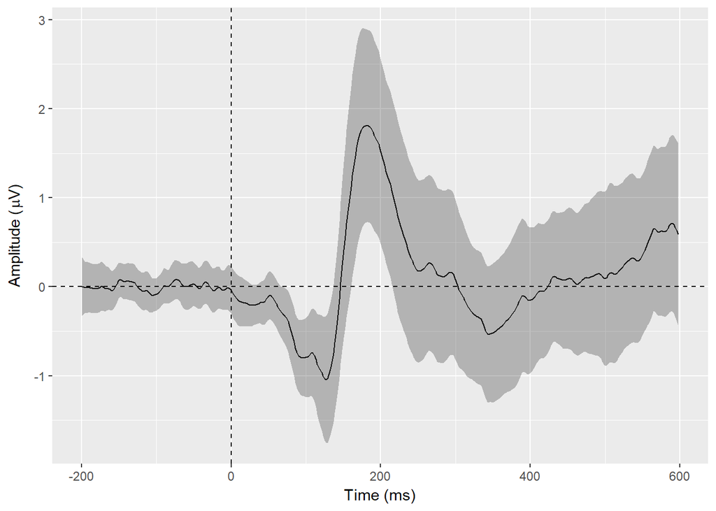

```r
ggplot()+
  geom_line(data = stat_out, aes(x = Time, y = estimate)) +
  geom_ribbon(data = stat_out, aes(ymax = conf.high, ymin = conf.low, x = Time, y = estimate), alpha = 0.3) +
  labs(x = "Time (ms)", y = expression(paste("Amplitude (", mu, "V)")), colour = "") +
  geom_vline(xintercept = 0, linetype = "dashed") +
  geom_hline(yintercept = 0, linetype = "dashed")
```

We can also add indicators of which timepoints are significant, and correct the p-values for multiple comparisons.

```r
stat_out$corr.p <- p.adjust(stat_out$p.value, method = "holm")
stat_out$p.sig <- 0 + (stat_out$p.value < .05)
stat_out$corr.p.sig <- 0 + (stat_out$corr.p < .05)
stat_out$p.sig[stat_out$p.sig == 0] <- NA
stat_out$corr.p.sig[stat_out$corr.p.sig == 0] <- NA
stat_out
```

```
## # A tibble: 409 x 12
##       Time     estimate   statistic   p.value parameter   conf.low
##      <dbl>        <dbl>       <dbl>     <dbl>     <dbl>      <dbl>
##  1 -199.22  0.003435778  0.02102066 0.9833242        44 -0.3259713
##  2 -197.27 -0.004607544 -0.03048767 0.9758160        44 -0.3091862
##  3 -195.31 -0.007631889 -0.05287681 0.9580694        44 -0.2985167
##  4 -193.36 -0.007660292 -0.05390409 0.9572556        44 -0.2940635
##  5 -191.41 -0.008548889 -0.06053518 0.9520035        44 -0.2931628
##  6 -189.45 -0.011082038 -0.07931093 0.9371449        44 -0.2926874
##  7 -187.50 -0.014025833 -0.10133764 0.9197428        44 -0.2929667
##  8 -185.55 -0.016931282 -0.12313070 0.9025643        44 -0.2940576
##  9 -183.59 -0.020056693 -0.14676507 0.8839879        44 -0.2954738
## 10 -181.64 -0.021509140 -0.15799361 0.8751847        44 -0.2958799
## # ... with 399 more rows, and 6 more variables: conf.high <dbl>,
## #   method <fctr>, alternative <fctr>, corr.p <dbl>, p.sig <dbl>,
## #   corr.p.sig <dbl>
```

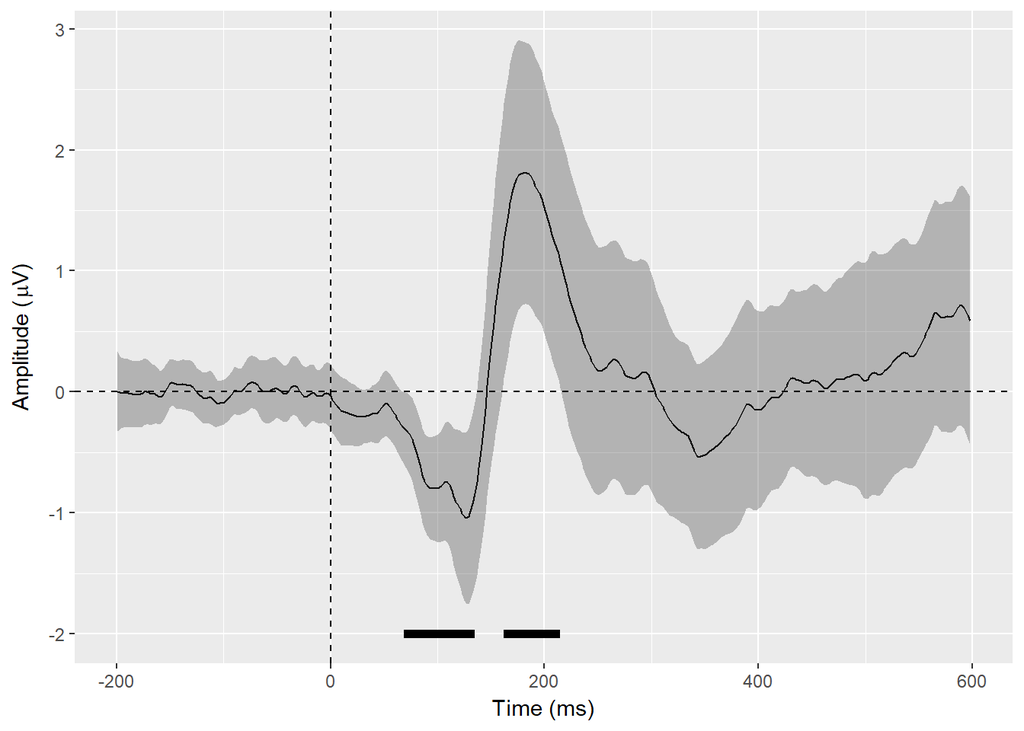

```r
ggplot()+
  geom_line(data = stat_out, aes(x = Time, y = estimate)) +
  geom_ribbon(data = stat_out, aes(ymax = conf.high, ymin = conf.low, x = Time, y = estimate), alpha = 0.3) +
  geom_line(data = stat_out, aes(x = Time, y = p.sig-3), size = 2)+
  labs(x = "Time (ms)", y = expression(paste("Amplitude (", mu, "V)")), colour = "") +
  geom_vline(xintercept = 0, linetype = "dashed") +
  geom_hline(yintercept = 0, linetype = "dashed")
```